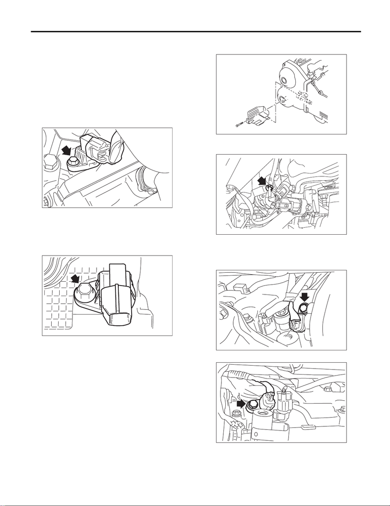

FU(STI)-35

Camshaft Position Sensor

FUEL INJECTION (FUEL SYSTEMS)

6. Camshaft Position Sensor

A: REMOVAL

1. INTAKE SIDE

• Camshaft position sensor RH

1) Disconnect the ground cable from battery.

2) Disconnect the connector (A) from the camshaft

position sensor RH, and remove the camshaft po-

sition sensor RH from the rear side of the cylinder

head.

• Camshaft position sensor LH

1) Disconnect the ground cable from battery.

2) Remove the intake manifold. <Ref. to FU(STI)-

17, REMOVAL, Intake Manifold.>

3) Remove the camshaft position sensor LH.

2. EXHAUST SIDE

1) Disconnect the ground cable from battery.

2) Lift up the vehicle.

3) Remove the under cover. <Ref. to EI-21, RE-

MOVAL, Front Under Cover.>

4) Remove the engine harness cover. (right side

only.)

5) Remove the clip holding the engine harness.

(Left side only)

6) Disconnect connector (A) from the camshaft po-

sition sensor, and remove the camshaft position

sensor from under the cylinder head.

•RH side

•LH side

FU-05840

(A)

FU-05841

FU-03616

FU-08481

FU-05801

(A)

FU-05826

(A)

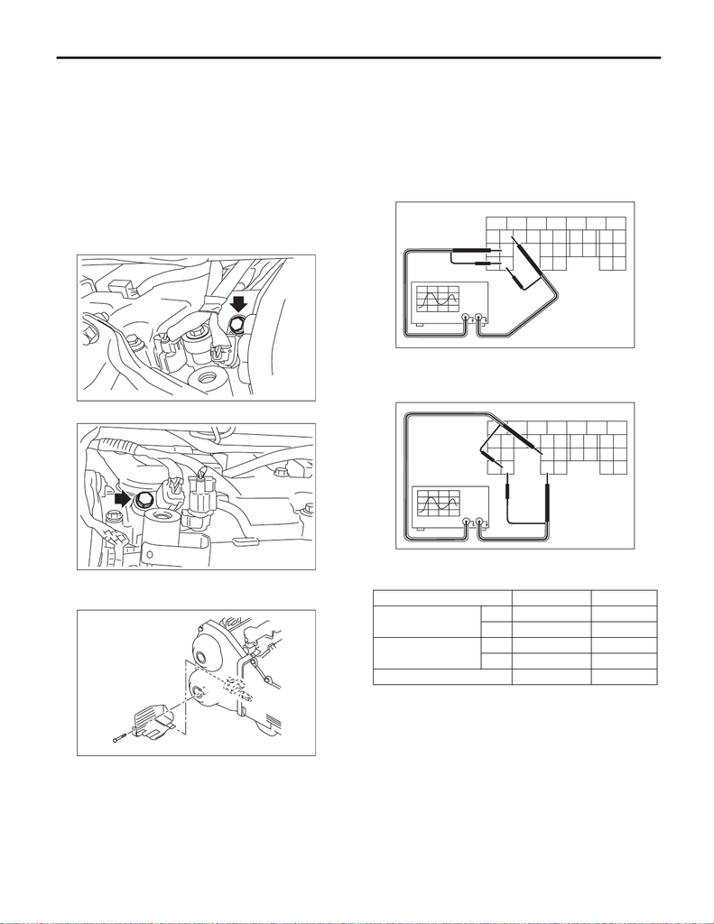

FU(STI)-36

Camshaft Position Sensor

FUEL INJECTION (FUEL SYSTEMS)

B: INSTALLATION

1. INTAKE SIDE

Install in the reverse order of removal.

Tightening torque:

6.4 N·m (0.7 kgf-m, 4.7 ft-lb)

2. EXHAUST SIDE

Install in the reverse order of removal.

Tightening torque:

6.4 N·m (0.7 kgf-m, 4.7 ft-lb)

• RH side

•LH side

Tightening torque:

5 N·m (0.5 kgf-m, 3.7 ft-lb)

C: INSPECTION

1. CAMSHAFT POSITION SENSOR (METH-

OD WITH OSCILLOSCOPE)

1) Prepare an oscilloscope.

2) Remove the glove box. <Ref. to EI-63, REMOV-

AL, Glove Box.>

3) Connect the probe to ECM connector.

• Intake camshaft position sensor

• Exhaust camshaft position sensor

4) Start the engine and let it idle.

FU-05793

FU-05827

FU-03616

(A) To ECM connector

(A) To ECM connector

Camshaft position sensor Terminal No. Probe

Intake

RH 24 +

LH 16 +

Exhaust

RH 23 +

LH 29 +

RH and LH 30 –

8

21

9

43

10

2425

26

1617

(A)

FU-04757

8

21

9

43

10

2425

26

1617

(A)

FU-04762

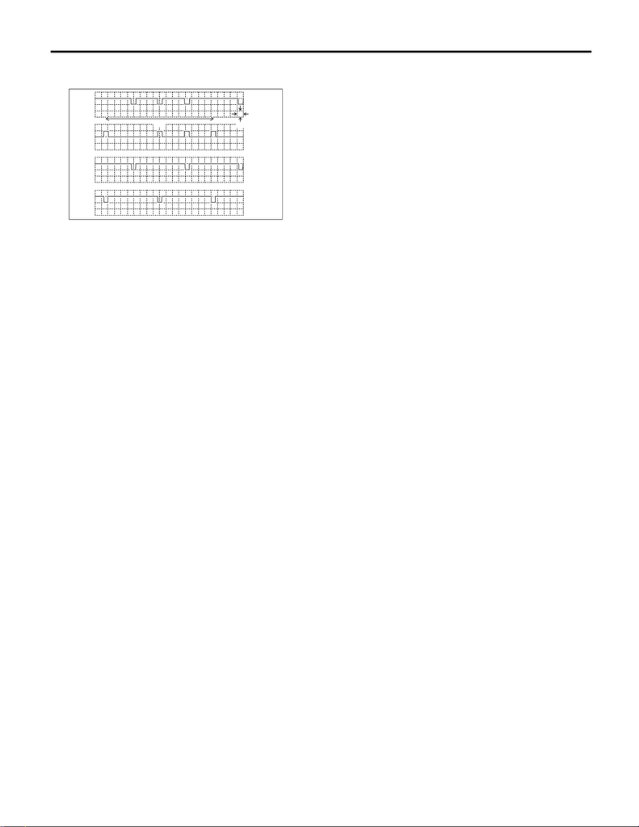

FU(STI)-37

Camshaft Position Sensor

FUEL INJECTION (FUEL SYSTEMS)

5) Check the pattern is the same as the waveform

and voltage shown below.

6) After inspection, install the related parts in the

reverse order of removal.

2. OTHER INSPECTIONS

Check that the camshaft position sensor has no de-

formation, cracks or other damages.

(A) One camshaft rotation

(B) Intake camshaft position sensor RH

(C) Intake camshaft position sensor LH

(D) Exhaust camshaft position sensor RH

(E) Exhaust camshaft position sensor LH

FU-04763

0

0

0

0

(A)

10ms

5V

(B)

(C)

(D)

(E)